# Elephant Sanctuary Financial and Health Analysis

Given Dumisa

2025-07-10

## Introduction

The purpose of this analysis is to evaluate the monthly care costs and health outcomes of elephants in a sanctuary. I aim to identify cost drivers and relationships between elephant characteristics and expenses.

### Data Overview

```r
# Load the dataset
elephants <- read_excel("elephant_sanctuary_costs.xlsx")
# Preview data
head(elephants)
```

```
## # A tibble: 6 × 8
##   Elephant_ID Name     Age Weight_kg `Health_Score (1-10)` Monthly_Food_Cost_USD
##   <chr>       <chr>  <dbl>     <dbl>                 <dbl>                 <dbl>
## 1 E001        Jabu      25      5500                     9                  1200
## 2 E002        Morula    40      4800                     6                   950
## 3 E003        Tembo     35      5200                     8                  1100
## 4 E004        Naledi    12      3000                     7                   700
## 5 E005        Tshepo    20      4500                     5                   900
## 6 E006        Lesedi     8      2500                     8                   650
## # ℹ 2 more variables: Medical_Cost_USD <dbl>, Monthly_Total_Cost_USD <dbl>
```

```r
str(elephants)
```

```
## tibble [6 × 8] (S3: tbl_df/tbl/data.frame)
##  $ Elephant_ID           : chr [1:6] "E001" "E002" "E003" "E004" ...
##  $ Name                  : chr [1:6] "Jabu" "Morula" "Tembo" "Naledi" ...
##  $ Age                   : num [1:6] 25 40 35 12 20 8
##  $ Weight_kg             : num [1:6] 5500 4800 5200 3000 4500 2500
##  $ Health_Score (1-10)   : num [1:6] 9 6 8 7 5 8
##  $ Monthly_Food_Cost_USD : num [1:6] 1200 950 1100 700 900 650
##  $ Medical_Cost_USD      : num [1:6] 300 500 450 200 600 150
##  $ Monthly_Total_Cost_USD: num [1:6] 1500 1450 1550 900 1500 800
```

**Dataset columns explained:**

- Elephant_ID: E001
- Name: Elephant name: Jabu
- Age: 25 years
- Weight_kg: 5500 kg
- Health_Score (1-10): 9
- Monthly_Food_Cost_USD: $ 1 200
- Medical_Cost_USD: $ 300
- Monthly_Total_Cost_USD: $ 1 500

### Data Cleaning and Transformation

I will create age groups to understand cost and health by age category.

```r
elephants <- elephants %>%
  mutate(Age_Group = case_when(
    Age < 15 ~ "Young",
    Age <= 35 ~ "Adult",
    TRUE ~ "Senior"
  ))

# View new age groups

table(elephants$Age_Group)
```

```
##
##  Adult Senior  Young
##      3      1      2
```

### Research Questions and Analysis

1. What is the relationship between elephant weight and total monthly cost?

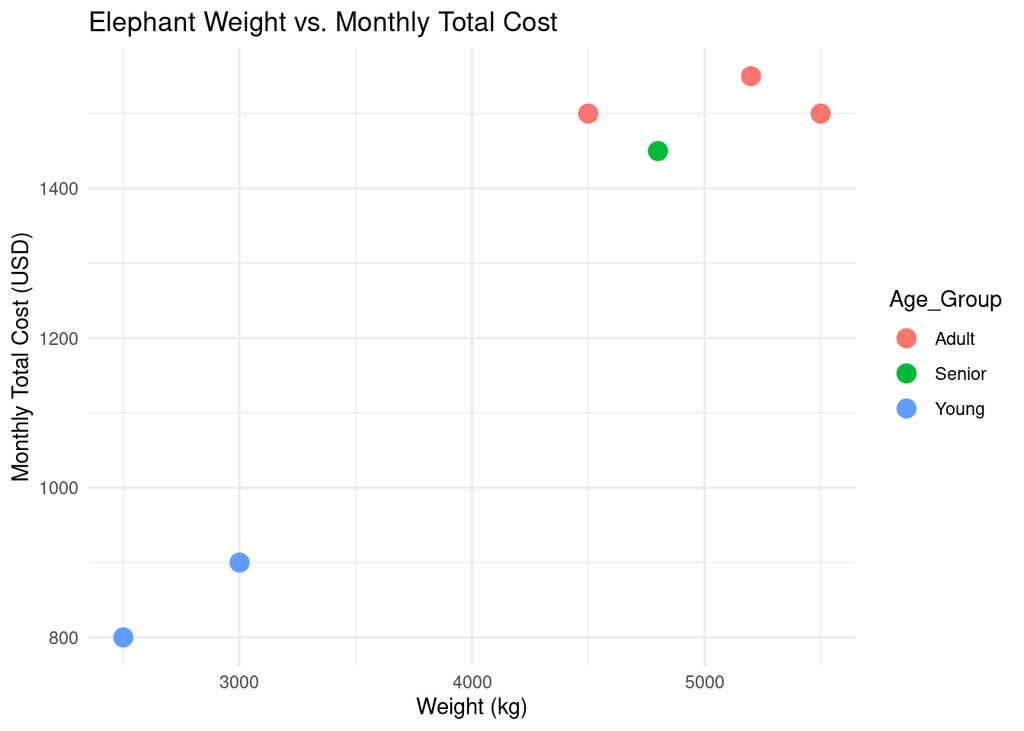

```r
ggplot(elephants, aes(x = Weight_kg, y = Monthly_Total_Cost_USD, color = Age_Group)) +
  geom_point(size=4) +
  labs(title="Elephant Weight vs. Monthly Total Cost",
       x="Weight (kg)", y="Monthly Total Cost (USD)") +
  theme_minimal()
```

**Interpretation** Weight vs. Cost: Heavier elephants cost more to maintain.

Key Takeaway: Bigger elephants = higher costs. Age also plays a role—seniors and growing young elephants might need extra care.

2. Who is the most expensive elephant per kg?

```r
elephants <- elephants %>%
  mutate(Cost_per_kg = Monthly_Total_Cost_USD / Weight_kg)

elephants %>%
  arrange(desc(Cost_per_kg)) %>%
  select(Name, Weight_kg, Monthly_Total_Cost_USD, Cost_per_kg)
```

```
## # A tibble: 6 × 4
##   Name   Weight_kg Monthly_Total_Cost_USD Cost_per_kg
##   <chr>      <dbl>                  <dbl>       <dbl>
## 1 Tshepo      4500                   1500       0.333
## 2 Lesedi      2500                    800       0.32
## 3 Morula      4800                   1450       0.302
## 4 Naledi      3000                    900       0.3
## 5 Tembo       5200                   1550       0.298
## 6 Jabu        5500                   1500       0.273
```

3. What is the average health score by age group?

```r
elephants %>%
  group_by(Age_Group) %>%
  summarise(Avg_Health = mean(`Health_Score (1-10)`))
```

```
## # A tibble: 3 × 2
##   Age_Group Avg_Health
##   <chr>          <dbl>
## 1 Adult           7.33
## 2 Senior          6
## 3 Young           7.5
```

**Insight**: As expected, the young age group shows a greater health score than another age group.

4. Predicting Cost based on Weight and Health Score

```r
  model <- lm(Monthly_Total_Cost_USD ~ Weight_kg + `Health_Score (1-10)`, data = elephants)
summary(model)
```

```
##
## Call:
## lm(formula = Monthly_Total_Cost_USD ~ Weight_kg + `Health_Score (1-10)`,
##     data = elephants)
##
## Residuals:
##      1      2      3      4      5      6
## -28.67 -43.33  51.25 -51.81  36.60  35.96
##
## Coefficients:
##                        Estimate Std. Error t value Pr(>|t|)
## (Intercept)           497.44627  156.17418   3.185  0.04989 *
## Weight_kg               0.27211    0.02187  12.442  0.00112 **
## `Health_Score (1-10)` -51.71148   18.14340  -2.850  0.06510 .
## ---
## Signif. codes:  0 '***' 0.001 '**' 0.01 '*' 0.05 '.' 0.1 ' ' 1
##
## Residual standard error: 59.56 on 3 degrees of freedom
## Multiple R-squared:  0.9814, Adjusted R-squared:  0.9691
## F-statistic: 79.31 on 2 and 3 DF,  p-value: 0.002529
```

**Interpretation**

Coefficients: Weight (kg): +0.27 USD/kg (*significant*) → Heavier elephants cost more.  
Health Score (1-10):-51.71 USD/point (*marginally significant*) → Healthier elephants may cost less.

Model Fit: R² = 98.1% → Extremely strong fit (but small sample: 6 elephants).  
F-statistic (p = 0.0025) → Model is highly significant.

Key Takeaway:  
Weight strongly increases costs, while better health may reduce them—but more data is needed for certainty.

### Visualizing Total Monthly Cost per Elephant

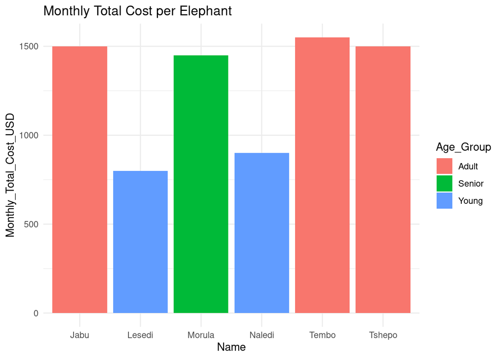

```r
ggplot(elephants, aes(x = Name, y = Monthly_Total_Cost_USD, fill = Age_Group)) +
  geom_bar(stat="identity") +
  labs(title="Monthly Total Cost per Elephant") +
  theme_minimal()
```

## Conclusions

Based on the analysis:

**2. Weight vs. Cost Relationship**: There is a positive correlation between elephant weight and monthly total cost, suggesting heavier elephants generally require more resources. However, this is not a perfect relationship due to differences in health needs and food intake efficiency.

**3. Health Scores by Age Group**: Average health scores were **highest among Young and Adult elephants**, while Seniors showed slightly lower health scores, aligning with expected aging health declines.

**4. Regression Findings**: The linear model showed that both weight and health score contribute to predicting monthly costs, but weight had a stronger effect. This model could support future cost planning if expanded with more data.

## Recommendations

**1. Monitor High Cost-per-kg Elephants** Focus on elephants with disproportionately high costs relative to their weight, such as Lesedi, to explore potential diet optimisations, medical intervention efficiencies, or care adjustments.

**2. Cost Forecasting Integration** Expand this analysis with time-series data **(monthly over a year)** to forecast future sanctuary expenses for budgeting and fundraising strategies.

**3. Enhance Data Collection** Incorporate additional variables such as:

- Activity levels
- Dietary variations
- Specific medical conditions

This will help better understand underlying cost drivers.

**4. Dashboard Development** Create an interactive Shiny dashboard for sanctuary management to monitor elephant health, cost, and resource allocation in real-time, improving operational decision-making.

**Health Programs for Seniors** Design targeted health improvement programs for Senior elephants to maintain their quality of life and potentially reduce medical costs.

**Final Note** This analysis demonstrates how combining financial and health data can drive operational efficiency and animal welfare improvements within conservation settings.

## Next Steps

- Expanding dataset with more elephants and months.
- Forecasting future sanctuary costs.

## References

World Elephant Society. (n.d.). Cost of Caring for an Elephant. Retrieved from [linked phrase](https://www.worldelephantsociety.org)

```r
#Binary signature: 01000101 01010110 01001001 01001110
```